# Table of Contents

- **Matplotlib** is a python 2D and 3D plotting library which produces scientific figures and publication quality figures.
- Great control of every element in a figure.
- High-quality output in many formats, including PNG, PDF, SVG, EPS, and PGF.
- More information at the Matplotlib web page: http://matplotlib.org/

# pyplot

- `pyplot` provides a procedural interface to the matplotlib object-oriented plotting library.
- It is modeled closely after Matlab™. Therefore, the majority of plotting commands in pyplot have Matlab™ analogs with similar arguments.

# Simple Plot

- Draw the cosine and sine functions on the same plot.
- First step is to get the data for the sine and cosine functions.

```python
import numpy as np
```

```python
X = np.linspace(-np.pi, np.pi, 256)
X
```

[output not shown]

```python
C, S = np.cos(X), np.sin(X)
```

```python
C
```

[output not shown]

```python
S
```

[output not shown]

[output cut: 9 more lines]

[output not shown]

## Plotting with default settings

- Matplotlib comes with a set of default settings that allow customizing all kinds of properties.
- You can control the defaults of almost every property in matplotlib: (figure size and dpi, line width, color and style, axes, axis and grid properties, text and font properties and so on.)

```python
import matplotlib.pyplot as plt
```

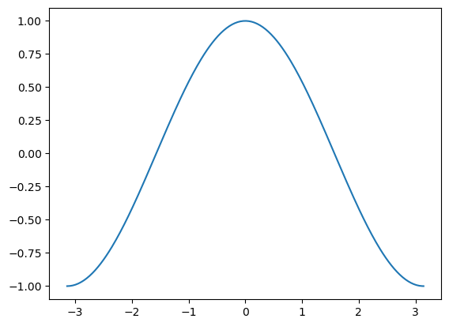

```python
plt.plot(X, C)
plt.show()
```

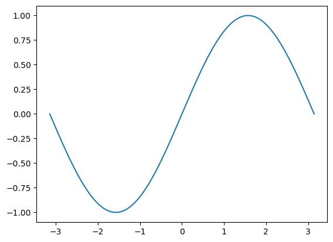

```python
plt.plot(X, S)
plt.show()
```

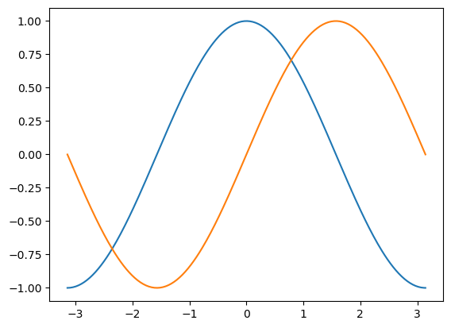

```python
plt.plot(X, C)
plt.plot(X, S)
plt.show()
```

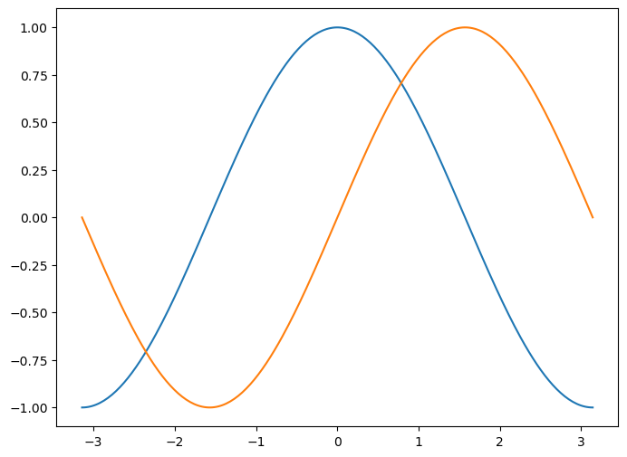

```python
# Create a figure of size 8x6 inches~16cm, 80 dots per inch
plt.figure(figsize=(8, 6), dpi=100)

plt.plot(X, C)
plt.plot(X, S)
plt.show()
```

## Set Figure Size and Subplot

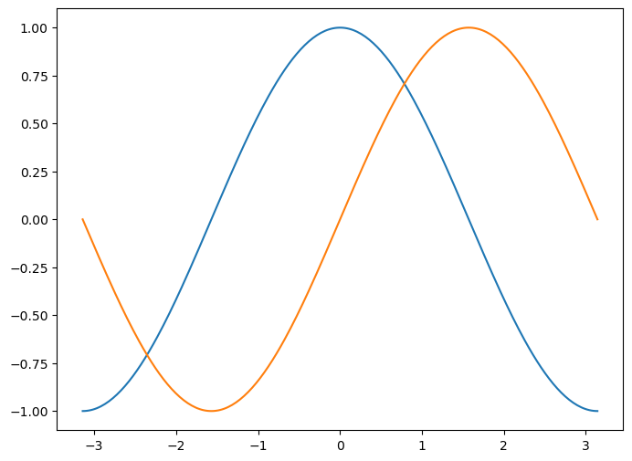

```python
# Create a figure of size 8x6 inches~16cm, 80 dots per inch
plt.figure(figsize=(8, 6), dpi=100)

# Create a new subplot from a grid of 1x1
plt.subplot(1, 1, 1)

plt.plot(X, C)
plt.plot(X, S)
plt.show()
```

### Set Color, Linewidth, Linestyle

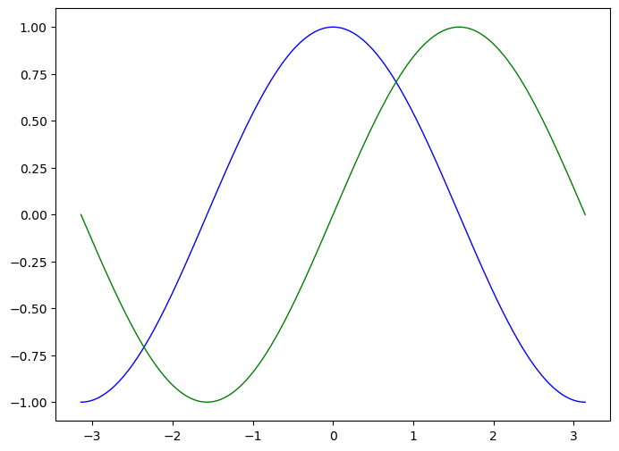

```python
# Create a figure of size 8x6 inches~16cm, 80 dots per inch
plt.figure(figsize=(8, 6), dpi=100)

# Create a new subplot from a grid of 1x1
plt.subplot(1, 1, 1)

# Plot cosine with a blue continuous line of width 1 (pixels)
plt.plot(X, C, color="blue", linewidth=1.0, linestyle="-")

# Plot sine with a green continuous line of width 1 (pixels)
plt.plot(X, S, color="green", linewidth=1.0, linestyle="-")

plt.show()
```

### Set X-limits, Y-limits, X-ticks, Y-ticks

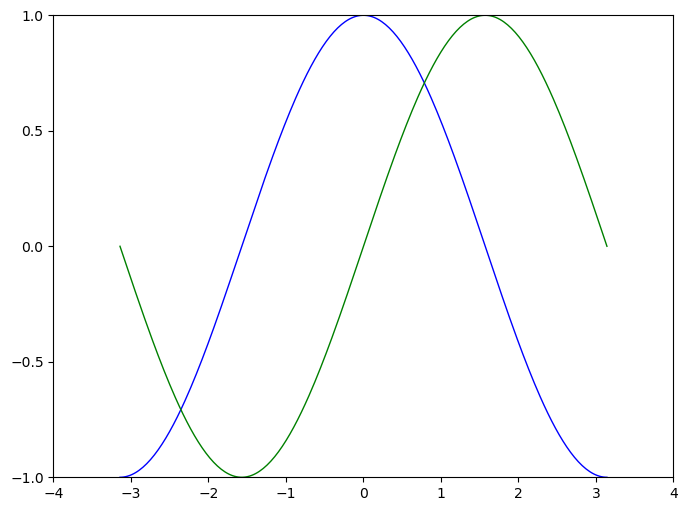

```python
# Create a figure of size 8x6 inches~16cm, 80 dots per inch
plt.figure(figsize=(8, 6), dpi=100)

# Create a new subplot from a grid of 1x1
plt.subplot(1, 1, 1)

# Plot cosine with a blue continuous line of width 1 (pixels)
plt.plot(X, C, color="blue", linewidth=1.0, linestyle="-")

# Plot sine with a green continuous line of width 1 (pixels)
plt.plot(X, S, color="green", linewidth=1.0, linestyle="-")

# Set x limits
plt.xlim(-4.0, 4.0)

# Set x ticks
plt.xticks(np.linspace(-4, 4, 9))

# Set y limits
plt.ylim(-1.0, 1.0)

# Set y ticks
plt.yticks(np.linspace(-1, 1, 5))

plt.show()
```

### Save Figure

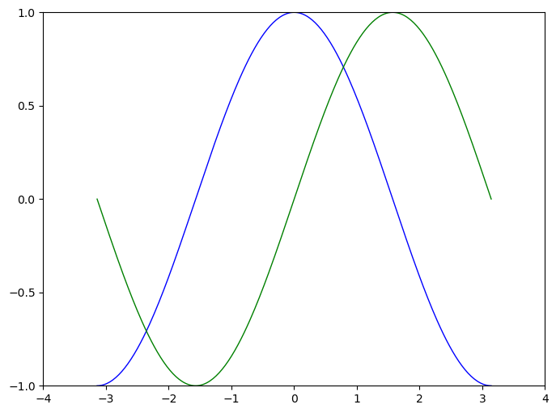

```python
# Create a figure of size 8x6 inches~16cm, 80 dots per inch
plt.figure(figsize=(8, 6), dpi=100)

# Create a new subplot from a grid of 1x1
plt.subplot(1, 1, 1)

# Plot cosine with a blue continuous line of width 1 (pixels)
plt.plot(X, C, color="blue", linewidth=1.0, linestyle="-")

# Plot sine with a green continuous line of width 1 (pixels)
plt.plot(X, S, color="green", linewidth=1.0, linestyle="-")

# Set x limits
plt.xlim(-4.0, 4.0)

# Set x ticks
plt.xticks(np.linspace(-4, 4, 9))

# Set y limits
plt.ylim(-1.0, 1.0)

# Set y ticks
plt.yticks(np.linspace(-1, 1, 5))

# Save figure using 80 dots per inch
plt.savefig("exercise_1.png", dpi=80)

# Show result on screen
plt.show()
```

### Moving Spines

- Spines are the lines connecting the axis tick marks.
- They can be placed at arbitrary positions and until now, they were on the border of the axis.

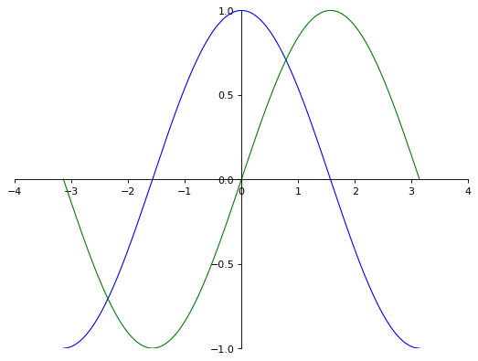

```python
# Create a figure of size 8x6 inches~16cm, 80 dots per inch
plt.figure(figsize=(8, 6), dpi=80)

# Create a new subplot from a grid of 1x1
plt.subplot(1, 1, 1)

X = np.linspace(-np.pi, np.pi, 256)
C, S = np.cos(X), np.sin(X)

# Plot cosine with a blue continuous line of width 1 (pixels)
plt.plot(X, C, color="blue", linewidth=1.0, linestyle="-")

# Plot sine with a green continuous line of width 1 (pixels)
plt.plot(X, S, color="green", linewidth=1.0, linestyle="-")

# Set x limits
plt.xlim(-4.0, 4.0)

# Set x ticks
plt.xticks(np.linspace(-4, 4, 9))

# Set y limits
plt.ylim(-1.0, 1.0)

# Set y ticks
plt.yticks(np.linspace(-1, 1, 5))

# gca stands for 'get current axis'

ax = plt.gca()

ax.spines['right'].set_color('none')

ax.spines['top'].set_color('none')

ax.xaxis.set_ticks_position('bottom')

ax.spines['bottom'].set_position(('data',0))

ax.yaxis.set_ticks_position('left')

ax.spines['left'].set_position(('data',0))

# Save figure using 72 dots per inch
# plt.savefig("exercise_2.png", dpi=72)

# Show result on screen
plt.show()
```

## Adding Legend

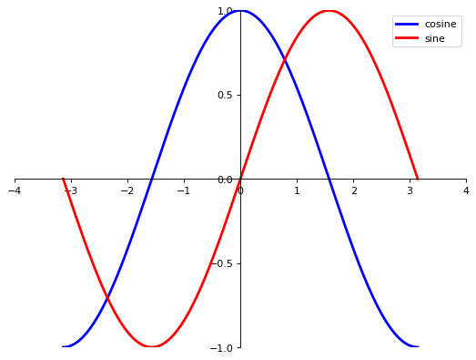

```python
# Create a figure of size 8x6 inches~16cm, 80 dots per inch
plt.figure(figsize=(8, 6), dpi=80)

# Create a new subplot from a grid of 1x1
plt.subplot(1, 1, 1)

X = np.linspace(-np.pi, np.pi, 256)
C, S = np.cos(X), np.sin(X)

# Add legend
plt.plot(X, C, color="blue", linewidth=2.5, linestyle="-", label="cosine")
plt.plot(X, S, color="red",  linewidth=2.5, linestyle="-", label="sine")
plt.legend(loc='best')

# 'upper left', 'upper right', 'lower left', 'lower right'
# 'upper center', 'lower center', 'center left', 'center right'
# 'center'
# 'best'


# Set x limits
plt.xlim(-4.0, 4.0)

# Set x ticks
plt.xticks(np.linspace(-4, 4, 9))

# Set y limits
plt.ylim(-1.0, 1.0)

# Set y ticks
plt.yticks(np.linspace(-1, 1, 5))

# gca stands for 'get current axis'

ax = plt.gca()

ax.spines['right'].set_color('none')

ax.spines['top'].set_color('none')

ax.xaxis.set_ticks_position('bottom')

ax.spines['bottom'].set_position(('data',0))

ax.yaxis.set_ticks_position('left')

ax.spines['left'].set_position(('data',0))

# Save figure using 72 dots per inch
# plt.savefig("exercise_2.png", dpi=72)

# Show result on screen
plt.show()
```

## Other Types of Plots

### Scatter Plot

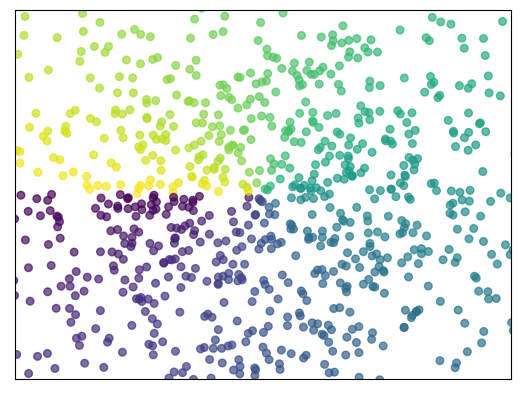

```python
n = 1024
X = np.random.normal(0, 1, n)
Y = np.random.normal(0, 1, n)
T = np.arctan2(Y, X)

plt.scatter(X, Y, s=30, c=T, alpha=.7)

plt.xlim(-1.5, 1.5)
plt.xticks([])

plt.ylim(-1.5, 1.5)
plt.yticks([])

plt.show()
```

### Bar Plots

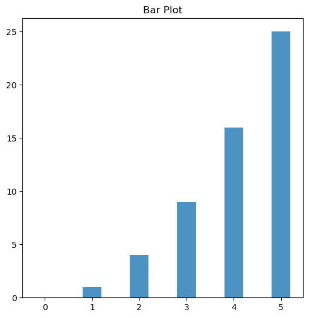

```python
fig, ax = plt.subplots(figsize=(6,6))

n = np.array([0,1,2,3,4,5])

ax.bar(n, n**2, align="center", width=0.4, alpha=0.8)

ax.set_title("Bar Plot")
```

### Contour Plot

- It is useful to display **3-dimensional** data in **2-dimensions** using **contours** or **color-coded regions**.
- There are three **Matplotlib** functions that can be helpful for this task:
  - `plt.contour` for contour plots
  - `plt.contourf` for filled contour plots
  - `plt.imshow` for showing images
- A contour plot can be created with the plt.contour function.
- It takes three arguments:
  - a grid of x values,
  - a grid of y values,
  - a grid of z values.
- The x and y values represent positions on the plot, and the z values will be represented by the contour levels.
- To prepare such data is to use the `np.meshgrid` function, which builds two-dimensional grids from one-dimensional arrays.

### Creating a "meshgrid"

```python
xlist = np.linspace(-3.0, 3.0, 3)
ylist = np.linspace(-3.0, 3.0, 4)
X, Y = np.meshgrid(xlist, ylist)
```

```python
print(xlist)
print(ylist)
```

```
[-3.  0.  3.]
[-3. -1.  1.  3.]
```

```python
print(X)
```

```
[[-3.  0.  3.]
 [-3.  0.  3.]
 [-3.  0.  3.]
 [-3.  0.  3.]]
```

```python
print(Y)
```

```
[[-3. -3. -3.]
 [-1. -1. -1.]
 [ 1.  1.  1.]
 [ 3.  3.  3.]]
```

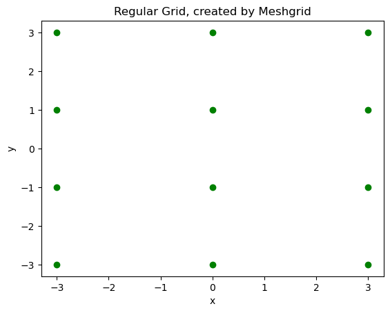

```python
fig, ax = plt.subplots()

ax.scatter(X, Y, color="green")
ax.set_title('Regular Grid, created by Meshgrid')
ax.set_xlabel('x')
ax.set_ylabel('y')
plt.show()
```

```python
# First let's define a function `z=f(x,y)`
def f(x, y):
    return np.sin(x) ** 10 + np.cos(10 + y * x) * np.cos(x)
```

```python
x = np.linspace(0, 5, 50)
x
```

```
array([0.        , 0.10204082, 0.20408163, 0.30612245, 0.40816327,
       0.51020408, 0.6122449 , 0.71428571, 0.81632653, 0.91836735,
       1.02040816, 1.12244898, 1.2244898 , 1.32653061, 1.42857143,
       1.53061224, 1.63265306, 1.73469388, 1.83673469, 1.93877551,
       2.04081633, 2.14285714, 2.24489796, 2.34693878, 2.44897959,
       2.55102041, 2.65306122, 2.75510204, 2.85714286, 2.95918367,
       3.06122449, 3.16326531, 3.26530612, 3.36734694, 3.46938776,
       3.57142857, 3.67346939, 3.7755102 , 3.87755102, 3.97959184,
       4.08163265, 4.18367347, 4.28571429, 4.3877551 , 4.48979592,
       4.59183673, 4.69387755, 4.79591837, 4.89795918, 5.        ])
```

```python
x.shape
```

```
(50,)
```

```python
y = np.linspace(0, 5, 40)
y
```

```
array([0.        , 0.12820513, 0.25641026, 0.38461538, 0.51282051,
       0.64102564, 0.76923077, 0.8974359 , 1.02564103, 1.15384615,
       1.28205128, 1.41025641, 1.53846154, 1.66666667, 1.79487179,
       1.92307692, 2.05128205, 2.17948718, 2.30769231, 2.43589744,
       2.56410256, 2.69230769, 2.82051282, 2.94871795, 3.07692308,
       3.20512821, 3.33333333, 3.46153846, 3.58974359, 3.71794872,
       3.84615385, 3.97435897, 4.1025641 , 4.23076923, 4.35897436,
       4.48717949, 4.61538462, 4.74358974, 4.87179487, 5.        ])
```

```python
y.shape
```

```
(40,)
```

```python
X, Y = np.meshgrid(x, y)
```

```python
X
```

```
array([[0.        , 0.10204082, 0.20408163, ..., 4.79591837, 4.89795918,
        5.        ],
       [0.        , 0.10204082, 0.20408163, ..., 4.79591837, 4.89795918,
        5.        ],
       [0.        , 0.10204082, 0.20408163, ..., 4.79591837, 4.89795918,
        5.        ],
       ...,
       [0.        , 0.10204082, 0.20408163, ..., 4.79591837, 4.89795918,
        5.        ],
       [0.        , 0.10204082, 0.20408163, ..., 4.79591837, 4.89795918,
        5.        ],
       [0.        , 0.10204082, 0.20408163, ..., 4.79591837, 4.89795918,
        5.        ]])
```

```python
X.shape
```

```
(40, 50)
```

```python
Y
```

```
array([[0.        , 0.        , 0.        , ..., 0.        , 0.        ,
        0.        ],
       [0.12820513, 0.12820513, 0.12820513, ..., 0.12820513, 0.12820513,
        0.12820513],
       [0.25641026, 0.25641026, 0.25641026, ..., 0.25641026, 0.25641026,
        0.25641026],
       ...,
       [4.74358974, 4.74358974, 4.74358974, ..., 4.74358974, 4.74358974,
        4.74358974],
       [4.87179487, 4.87179487, 4.87179487, ..., 4.87179487, 4.87179487,
        4.87179487],
       [5.        , 5.        , 5.        , ..., 5.        , 5.        ,
        5.        ]])
```

```python
Y.shape
```

```
(40, 50)
```

```python
Z = f(X, Y)
```

```python
Z
```

```
array([[-0.83907153, -0.83470697, -0.8216586 , ...,  0.8956708 ,
         0.68617261,  0.41940746],
       [-0.83907153, -0.8275558 , -0.80744041, ...,  0.93467448,
         0.77467433,  0.55894214],
       [-0.83907153, -0.820263  , -0.79266951, ...,  0.98503397,
         0.88847607,  0.73757604],
       ...,
       [-0.83907153, -0.48696962, -0.02692065, ...,  0.98525345,
         0.79584263,  0.46799565],
       [-0.83907153, -0.47558005, -0.00130271, ...,  0.93488414,
         0.6993547 ,  0.37933079],
       [-0.83907153, -0.46410908,  0.02431613, ...,  0.89579384,
         0.65690314,  0.40107702]])
```

```python
Z.shape
```

```
(40, 50)
```

### Contour

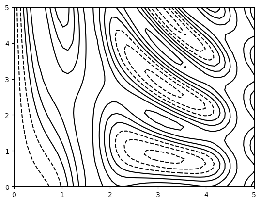

```python
plt.contour(X, Y, Z, colors='black');
```

- when a single color is used, negative values are represented by dashed lines, and positive values by solid lines.
- the lines can be color-coded by specifying a colormap with the cmap argument.
- we'll also specify that we want more lines to be drawn 20 equally spaced intervals within the data range.
- the `RdGy` (short for Red-Gray) colormap, which is a good choice for centered data.
- `Matplotlib` has a wide range of `colormaps` available.
- you can find the `colormaps` @ https://matplotlib.org/stable/tutorials/colors/colormaps.html

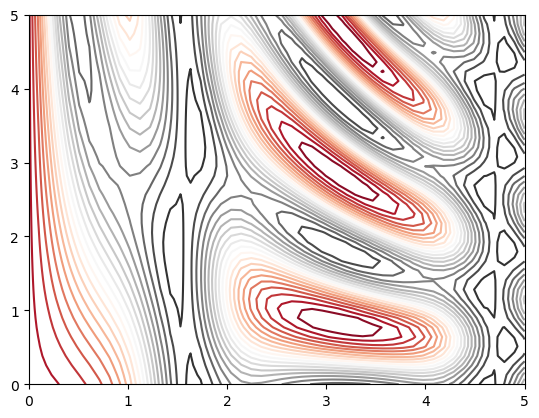

```python
plt.contour(X, Y, Z, 20, cmap='RdGy');
```

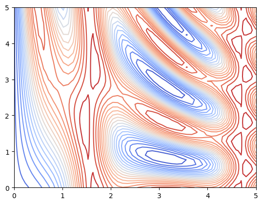

```python
plt.contour(X, Y, Z, 20, cmap='coolwarm');
```

- `plt.contourf()` can be used to fill the spaces between the lines.
- `plt.colorbar()` can be used to automatically creates an additional axis with labeled color information for the plot

### Contourf

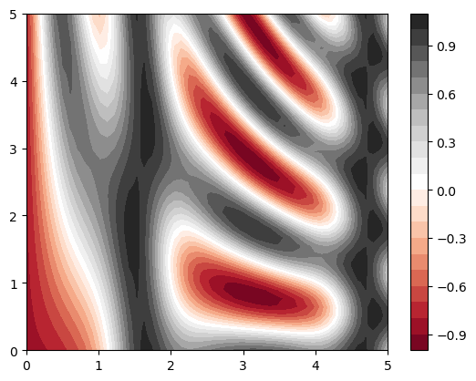

```python
plt.contourf(X, Y, Z, 20, cmap='RdGy')

plt.colorbar();
```

### imshow

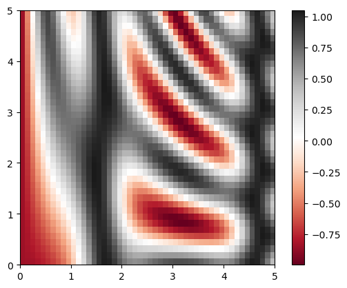

```python
plt.imshow(Z, extent=[0, 5, 0, 5], origin='lower', cmap='RdGy')
plt.colorbar()
```

### Contours + Imshow

- The combination of these three functions: `plt.contour`, `plt.contourf`, and `plt.imshow` gives nearly limitless possibilities for displaying `three-dimensional` and `two-dimensional` plot.

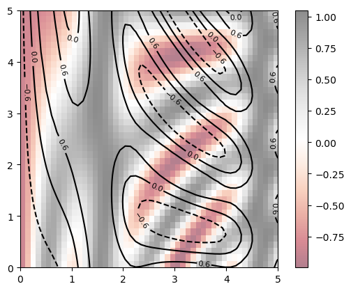

```python
contours = plt.contour(X, Y, Z, 3, colors='black')
plt.clabel(contours, inline=True, fontsize=8)

plt.imshow(Z, extent=[0, 5, 0, 5], cmap='RdGy', alpha=0.5)
plt.colorbar();
```

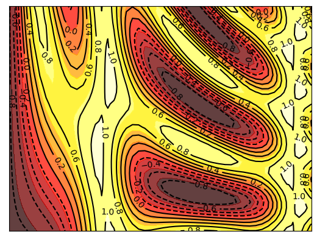

```python
plt.contourf(X, Y, f(X, Y), 8, alpha=.75, cmap=plt.cm.hot)

C = plt.contour(X, Y, f(X, Y), 10, colors='black')
plt.clabel(C, fontsize=10)

plt.xticks([])
plt.yticks([])
plt.show()
```

### Quiver Plots

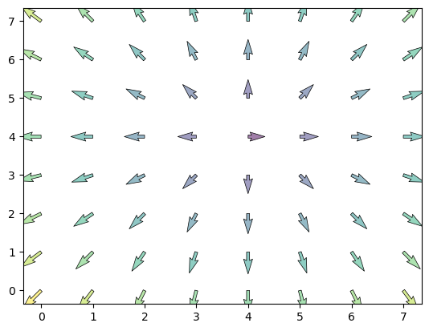

```python
n = 8
X, Y = np.mgrid[0:n, 0:n]

T = np.arctan2(Y - n / 2., X - n/2.)
R = 10 + np.sqrt((Y - n / 2.0) ** 2 + (X - n / 2.0) ** 2)

U, V = R * np.cos(T), R * np.sin(T)

plt.quiver(X, Y, U, V, R, alpha=.5)
plt.quiver(X, Y, U, V, edgecolor='k', facecolor='None', linewidth=.5)


plt.show()
```

### Grids

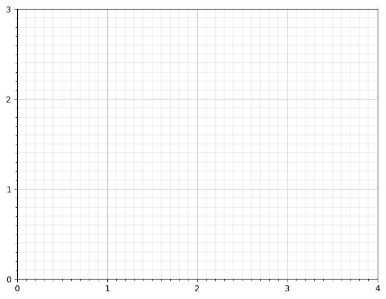

```python
ax = plt.axes([0.025, 0.025, 0.95, 0.95])

ax.set_xlim(0,4)
ax.set_ylim(0,3)

ax.xaxis.set_major_locator(plt.MultipleLocator(1.0))
ax.xaxis.set_minor_locator(plt.MultipleLocator(0.1))

ax.yaxis.set_major_locator(plt.MultipleLocator(1.0))
ax.yaxis.set_minor_locator(plt.MultipleLocator(0.1))

ax.grid(which='major', axis='x', linewidth=0.75, linestyle='-', color='0.75')
ax.grid(which='minor', axis='x', linewidth=0.25, linestyle='-', color='0.75')

ax.grid(which='major', axis='y', linewidth=0.75, linestyle='-', color='0.75')
ax.grid(which='minor', axis='y', linewidth=0.25, linestyle='-', color='0.75')
```

### 3D Plots

- To use 3D graphics in matplotlib, we first need to create an instance of the Axes3D class.
- 3D axes can be added to a matplotlib figure canvas in exactly the same way as 2D axes; or, more conveniently, by passing a projection='3d' keyword argument to the add_axes or add_subplot methods.

```python
from mpl_toolkits.mplot3d import Axes3D
```

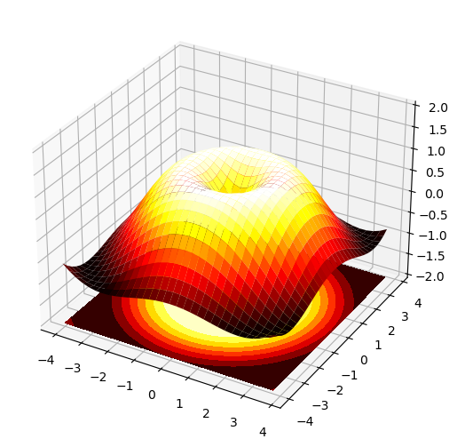

```python
fig = plt.figure()

ax = Axes3D(fig)

X = np.arange(-4, 4, 0.25)
Y = np.arange(-4, 4, 0.25)

X, Y = np.meshgrid(X, Y)

R = np.sqrt(X ** 2 + Y ** 2)
Z = np.sin(R)

ax.plot_surface(X, Y, Z, cmap=plt.cm.hot)
ax.contourf(X, Y, Z, zdir='z', offset=-2, cmap=plt.cm.hot)

ax.set_zlim(-2, 2)

plt.show()
```

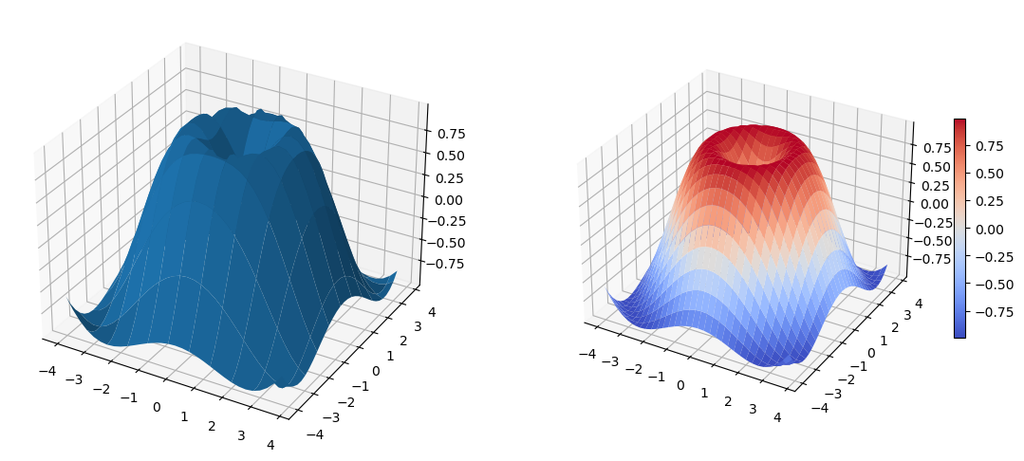

```python
fig = plt.figure(figsize=(14,6))

ax = fig.add_subplot(1, 2, 1, projection='3d')
p = ax.plot_surface(X, Y, Z, rstride=3, cstride=3, linewidth=1)

# surface_plot with color grading and color bar
ax = fig.add_subplot(1, 2, 2, projection='3d')

p = ax.plot_surface(X, Y, Z, rstride=1, cstride=1, cmap=plt.cm.coolwarm, linewidth=14)

cb = fig.colorbar(p, shrink=0.5)
```

#### Wire-frame plot

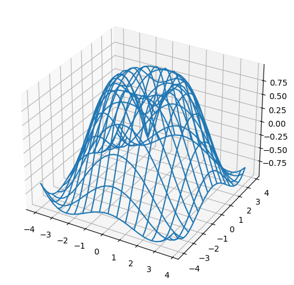

```python
fig = plt.figure(figsize=(8,6))

ax = fig.add_subplot(1, 1, 1, projection='3d')

p = ax.plot_wireframe(X, Y, Z, rstride=2, cstride=2)
```

### Subplot

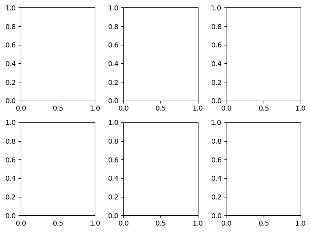

```python
fig, ax = plt.subplots(2, 3)
fig.tight_layout()
```